# 火锅团购分析

李云帆 16302010002

2019/4/10

## 0.预处理

```r
knitr::opts_chunk$set(echo = TRUE, message=FALSE, warning=FALSE)
cat("\014");rm(list=ls())
```

```r
par(family='STKaiti')
setwd("/Users/liyunfan/Desktop/数据挖掘/南山hw5/")
```

```r
# package setup
library(MASS)
library(readr)
library(dplyr)
library(stringr)
library(ggplot2)
library(gridExtra)
library(RColorBrewer)
```

## 1.数据概览

```r
hotpot <- read_csv("data/HotPotForMac.csv") #经过同学提醒，这个文件居然用utf8打不开，用Excel打开是乱码
names(hotpot)[2] <- "店名"
names(hotpot)[3] <- "团购信息"
colnames(hotpot)
```

```
##  [1] "ID"                            "店名"
##  [3] "团购信息"                      "discount"
##  [5] "price"                         "privilege.for.new"
##  [7] "privilege.on.sale"             "district"
##  [9] "if.nonworkdays.available"      "time.duration"
## [11] "if.appointment.needed"         "WiFi.available"
## [13] "parking"                       "rooms.available"
## [15] "评分"                          "评论数"
## [17] "online.intervel"               "quarterly.sales.volume"
## [19] "level.of.participants.limited" "level.of.tickets.limited"
## [21] "place"                         "food"
## [23] "taste"                         "cook"
## [25] "people"                        "style"
## [27] "HighFreq"
```

```r
summary(hotpot)
```

```
##        ID             店名             团购信息            discount
##  Min.   :   1.0   Length:2688        Length:2688        Min.   :0.01429
##  1st Qu.: 749.8   Class :character   Class :character   1st Qu.:0.63762
##  Median :1540.5   Mode  :character   Mode  :character   Median :0.76336
##  Mean   :1548.1                                         Mean   :0.72725
##  3rd Qu.:2350.2                                         3rd Qu.:0.85000
##  Max.   :3150.0                                         Max.   :0.99900
##      price         privilege.for.new  privilege.on.sale
##  Min.   :   1.00   Length:2688        Length:2688
##  1st Qu.:  68.00   Class :character   Class :character
##  Median :  86.05   Mode  :character   Mode  :character
##  Mean   : 109.74
##  3rd Qu.: 135.25
##  Max.   :1365.00
##    district         if.nonworkdays.available time.duration
##  Length:2688        Length:2688              Min.   : 0.00
##  Class :character   Class :character         1st Qu.:10.00
##  Mode  :character   Mode  :character         Median :11.00
##                                              Mean   :10.67
##                                              3rd Qu.:12.00
##                                              Max.   :24.00
##  if.appointment.needed WiFi.available       parking
##  Length:2688           Length:2688        Length:2688
##  Class :character      Class :character   Class :character
##  Mode  :character      Mode  :character   Mode  :character
##
##
##
##  rooms.available         评分           评论数        online.intervel
##  Length:2688        Min.   :0.000   Min.   :   0.00   Min.   :   1.0
##  Class :character   1st Qu.:0.000   1st Qu.:   0.00   1st Qu.: 191.0
##  Mode  :character   Median :4.400   Median :   3.00   Median : 320.5
##                     Mean   :3.167   Mean   :  54.49   Mean   : 341.2
##                     3rd Qu.:4.700   3rd Qu.:  22.00   3rd Qu.: 467.0
##                     Max.   :5.000   Max.   :8032.00   Max.   :1143.0
##  quarterly.sales.volume level.of.participants.limited
##  Min.   :    0.000      Length:2688
##  1st Qu.:    1.415      Class :character
##  Median :    9.441      Mode  :character
##  Mean   :  223.914
```

[output cut: 8 more lines]

```
##
##     taste               cook              people
##  Length:2688        Length:2688        Length:2688
##  Class :character   Class :character   Class :character
##  Mode  :character   Mode  :character   Mode  :character
##
##
##
##     style              HighFreq
##  Length:2688        Min.   :0.000
##  Class :character   1st Qu.:1.000
##  Mode  :character   Median :2.000
##                     Mean   :1.924
##                     3rd Qu.:3.000
##                     Max.   :6.000
```

## 2.季均销量与对数季均销量直方图

季均销量:

最小值 : 0 #销量为0的有276家

中位数 : 9.441

平均数 : 223.914

最大值 ： 25941.429 #销量最高的是“德乡园重庆火锅”

作季均销量的直方图，分布具有右偏性。

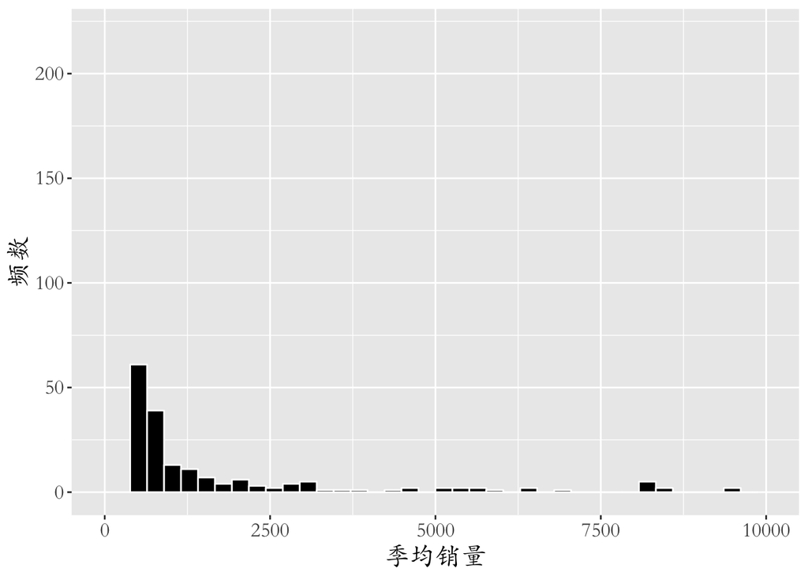

```r
# original sales
ggplot(data = hotpot, mapping = aes(x = quarterly.sales.volume)) +
  geom_histogram(fill = "black", color = 'white', bins=40) +
  xlab("季均销量") + ylab("频数") + xlim(c(0, 10000)) + ylim(c(0, 220)) +
  theme(text=element_text(size=16,family='STKaiti'))
```

再对log季均销量作个直方图

取对数的目的是使得分布变得相对均匀，可视化效果更好。

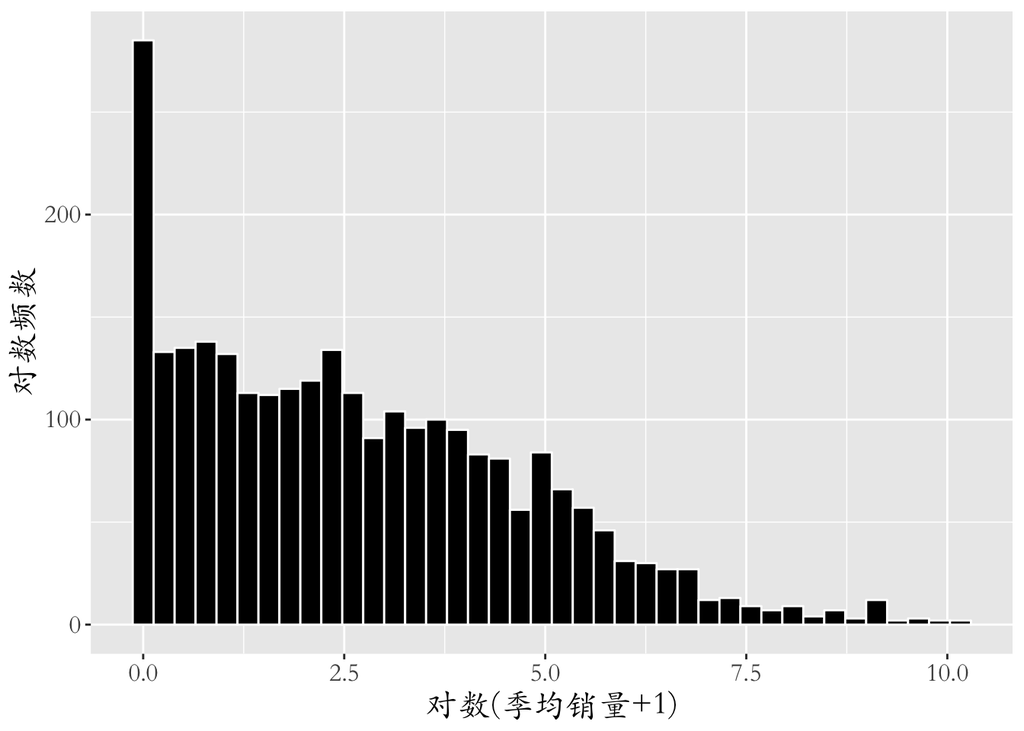

```r
# log sales
ggplot(data = hotpot, mapping = aes(x = log(quarterly.sales.volume+1))) +
  geom_histogram(fill = "black", color = 'white', color = 'white',bins = 40) +
  xlab("对数(季均销量+1)") + ylab("对数频数") +
  theme(text=element_text(size=16,family='STKaiti'))
```

## 3.团购上线天数 与 折扣力度 的分布情况

上线时间： 最小值 : 1 #上线时间的最小的是“香天下火锅” 中位数 : 320.5  
平均数 : 341.2 最大值 ： 1143.0 #上线时间的最长的是“京顺福火锅”

上线时间的分布具有右偏性

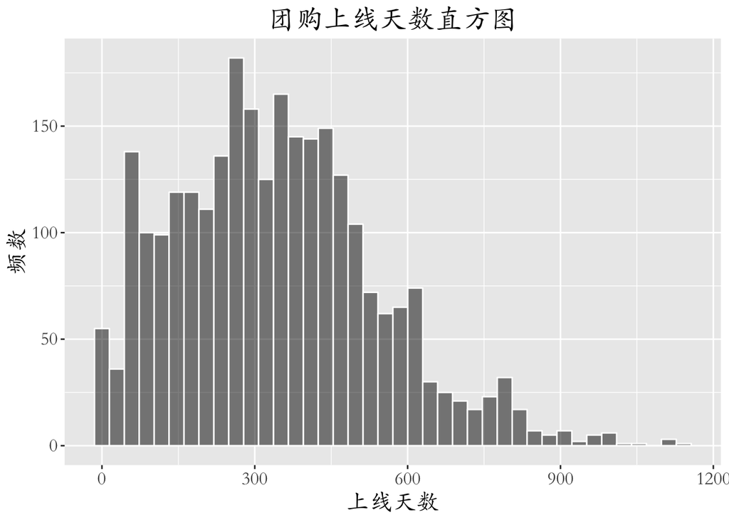

```r
ggplot(data = hotpot, mapping = aes(x = online.intervel)) +
  geom_histogram(fill = "black", color = 'white', alpha=0.5, bins = 40) +
  xlab("上线天数") + ylab("频数") +
  ggtitle(label = "团购上线天数直方图") +
  theme(plot.title = element_text(hjust = 0.5),text=element_text(size=16,family='STKaiti'))
```

团购折扣的分布具有左偏性

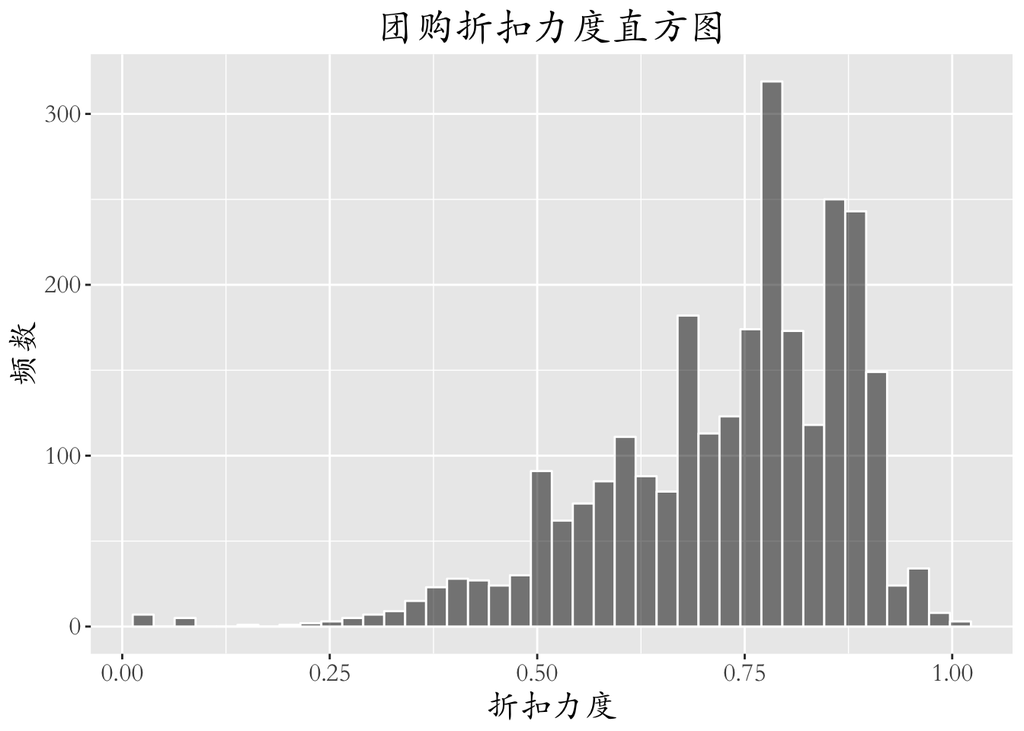

```r
ggplot(data = hotpot, mapping = aes(x = discount)) +
  geom_histogram(fill = "black", color = 'white', alpha=0.5, bins = 40) +
  xlab("折扣力度") + ylab("频数") +
  ggtitle("团购折扣力度直方图") +
  theme(plot.title = element_text(hjust = 0.5),text=element_text(size=16,family='STKaiti'))
```

## 4.店名词云

对店名进行jieba分词，使用top100的单词绘制词云。

```r
library(jiebaR)
library(wordcloud2)
worker <- worker(stop_word = "data/stopwords.txt",encoding = "GBK")
write_tsv(as.data.frame(hotpot$店名), path = "data/subset_restaurant.txt",col_names = FALSE)
# 对txt文件进行分词
segment("data/subset_restaurant.txt", worker)
```

```
## [1] "data/subset_restaurant.segment.2019-04-15_18_08_43.txt"
```

```r
W <- scan("data/subset_restaurant.segment.2019-04-15_11_42_16.txt", sep="\n", what="", encoding = "UTF-8")
Wfreq <- freq(worker[W])
Wfreq <- Wfreq[order(-Wfreq$freq),]
wordcloud2(Wfreq[1:100, ], size = 1, fontFamily = "微软雅黑"
           ,backgroundColor = 'black', color = "random-light")
```

[interactive chart not shown]

## 5.团购价对季均销量的影响

将价格划分为【“0-50”,“50-100”,“100-150”,“150-200”,“200-250”,“250-300”,“>300”】几类，绘制季均销量箱线图

可以看到，价格升高，团购销量呈下降趋势下降。但“>300”的箱子却偏离了走势，猜测高档消费具有不一样的商品属性。

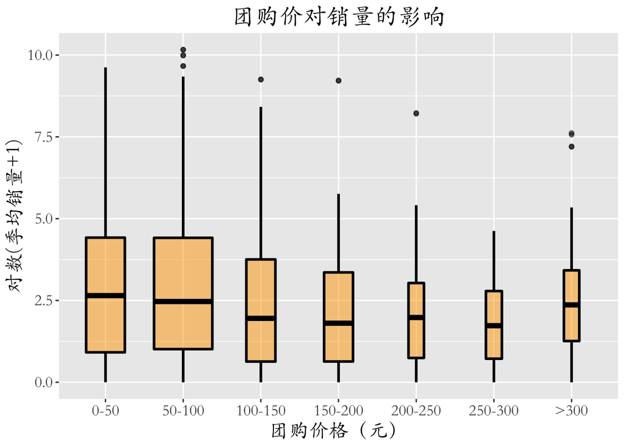

```r
hotpot$price.interval <- cut(hotpot$price, breaks = c(seq(0,300,50),max(hotpot$price)),
                               include.lowest = TRUE, right = FALSE, ordered_result = TRUE,
                               labels = c("0-50","50-100","100-150","150-200","200-250","250-300",">300"))

ggplot(data = hotpot, mapping = aes(x = price.interval, y = log(quarterly.sales.volume+1))) +
  geom_boxplot(alpha = 0.5, varwidth = TRUE, lwd = 1, fill = "orange" , color = "black") +
  ggtitle("团购价对销量的影响") + xlab("团购价格（元）") + ylab("对数(季均销量+1)") +
  theme(plot.title = element_text(hjust = 0.5),text=element_text(size=16,family='STKaiti'))
```

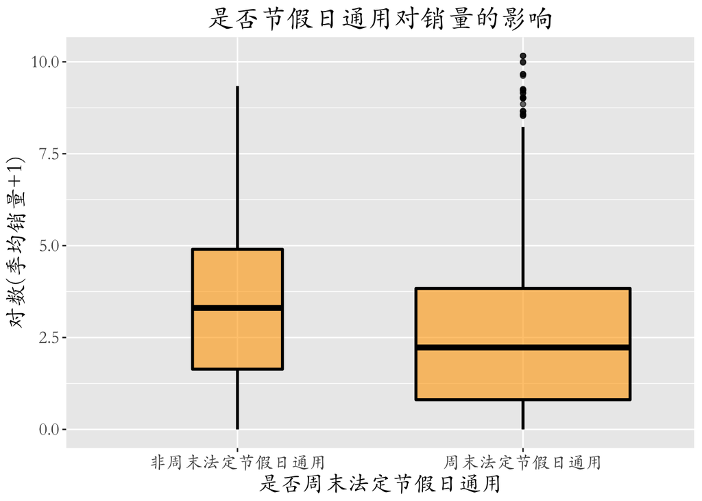

```r
ggplot(data = hotpot, mapping = aes(x = if.nonworkdays.available, y = log(quarterly.sales.volume+1))) +
  geom_boxplot(alpha = 0.6, varwidth = TRUE, lwd = 1,
               fill = "orange",color = "black") +
  ggtitle("是否节假日通用对销量的影响") +
  xlab("是否周末法定节假日通用") + ylab("对数(季均销量+1)") +

  theme(plot.title = element_text(hjust = 0.5),text=element_text(size=16,family='STKaiti'))
```

## 6.评分和销量的关系

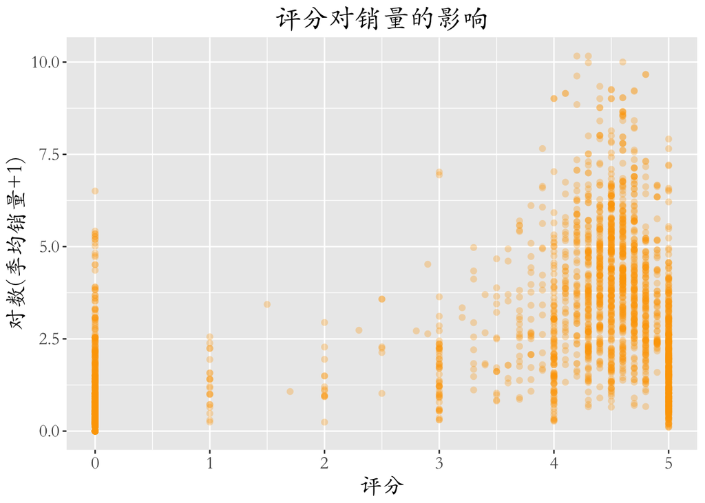

```r
ggplot(data = hotpot, aes(x = 评分, y = log(quarterly.sales.volume+1))) +
  geom_point(alpha = 0.3, color = "orange", size=2, shape=16) +
  xlab("评分") + ylab("对数(季均销量+1)") +
  ggtitle("评分对销量的影响") +

  theme(plot.title = element_text(hjust = 0.5),text=element_text(size=16,family='STKaiti'))
```

但注意到，评分为0的团购活动销量却不少。猜测是很多评分信息不准确。

## 7.人物词汇和销量的关系

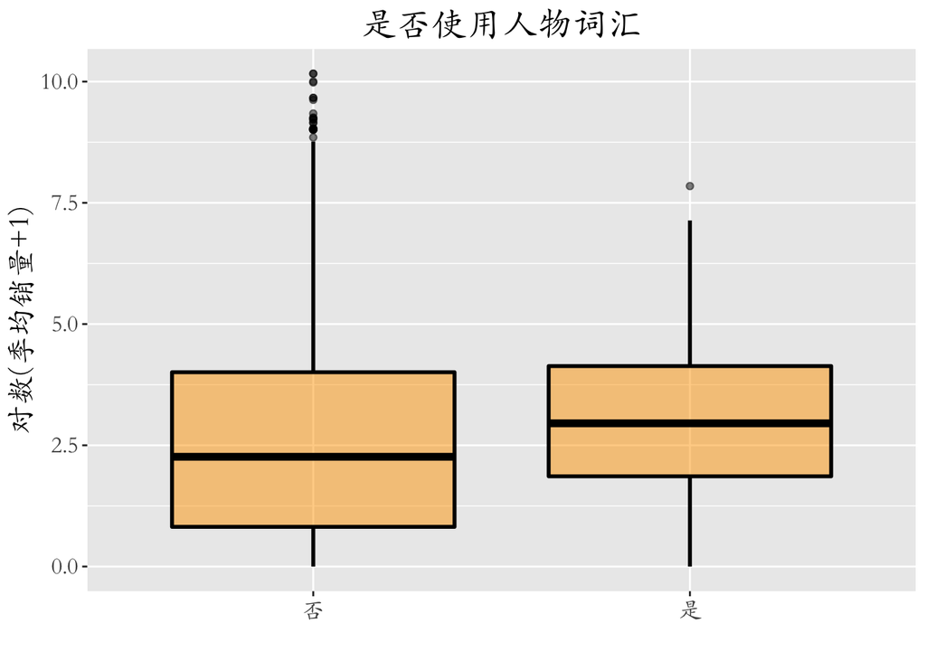

```r
ggplot(data = hotpot, aes(x = people, y = log(quarterly.sales.volume+1))) +
  geom_boxplot(alpha = 0.5, lwd=1,
               fill = "orange", color = "black")+
  xlab("") + ylab("对数(季均销量+1)") +
  ggtitle("是否使用人物词汇") +

  theme(plot.title = element_text(hjust = 0.5),text=element_text(size=16,family='STKaiti'))
```

店名中包含人物词汇的店家，销量相对更高，猜测是流量经济的产物。

但销量最高的却又往往店名不含人名（与同学讨论后发现），这个结论符合生活常识，且符合上述对流量经济为成因的推断。

## 8.高销量低销量分类

明显可以看出，销量高的是凤毛麟角，销量少的是普遍情况

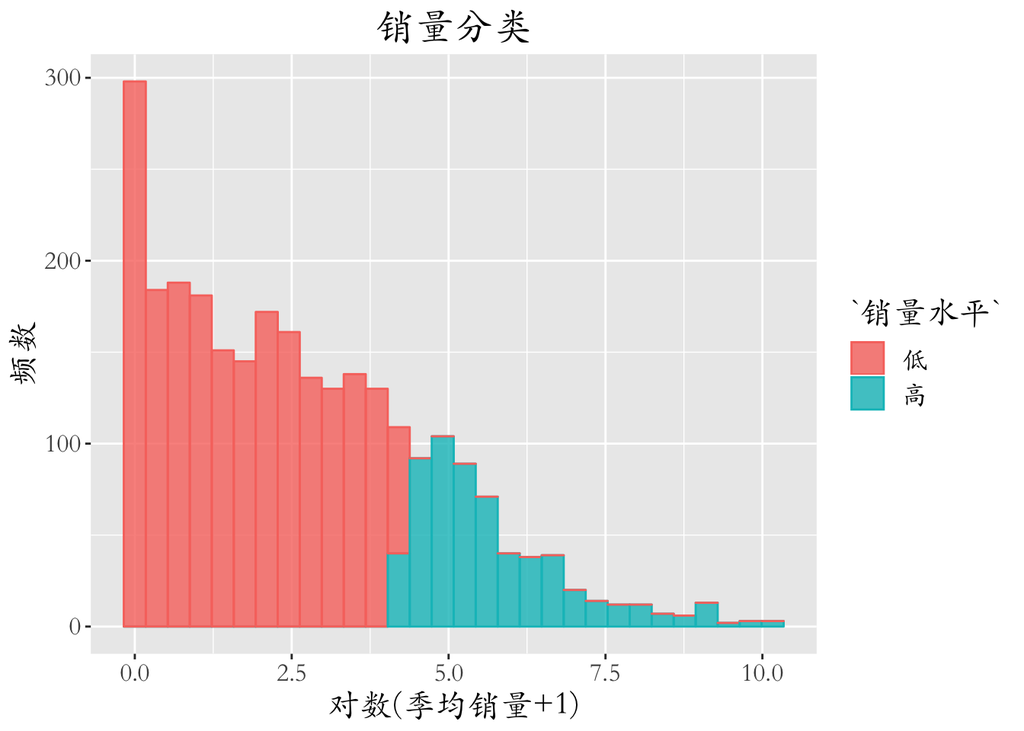

```r
hotpot$销量水平 <- cut(hotpot$quarterly.sales.volume, breaks = c(0, 68, max(hotpot$quarterly.sales.volume)),
                   right = FALSE, include.lowest = TRUE, labels = c("低", "高"))
ggplot(hotpot, aes(x=log(hotpot$quarterly.sales.volume+1))) +
  geom_histogram(aes(group=销量水平, colour=销量水平, fill=销量水平), alpha=0.8) +
  xlab("对数(季均销量+1)") + ylab("频数") + ggtitle("销量分类") +
  theme(plot.title = element_text(hjust = 0.5),text=element_text(size=16,family='STKaiti'))
```

## 9.逻辑回归

1.作为factor处理

2.对各个变量建立baseline。（上课的时候没太懂，这个部分在南山同学的指导下完成，可能有部分代码雷同）

课后的再次理解：

设置baseline的意义，在解读回归系数的时候，往往需要一个“基准”，其他的数据和基准比，和其中的哪个比较最说的通就选那个作为baseline

有时候baseline是谁都无所谓（比如地区类别），但有些情况，比如出现了“其他”类，这个时候让别的类别都和“其他”类做比较就比较合理。

```r
hotpot <- hotpot %>%
  mutate(district = relevel(district, ref = "碑林区"),
         privilege.on.sale = relevel(privilege.on.sale, ref = "无立减优惠"),
         privilege.for.new = relevel(privilege.for.new, ref = "无钱包新客优惠"),
         if.nonworkdays.available = relevel(if.nonworkdays.available, "非周末法定节假日通用"),
         if.appointment.needed = relevel(if.appointment.needed, "无需预约"),
         rooms.available = relevel(rooms.available, "未提及"),
         level.of.tickets.limited = relevel(level.of.tickets.limited, "不限张数"),
         parking = relevel(parking, "未提及"),
         place = relevel(place, "否"),
         taste = relevel(taste, "否"),
         food = relevel(food, "否"),
         people = relevel(people, "否"),
         cook = relevel(place, "否"),
         style = relevel(style, "其他"))
```

| 变量名 | Baseline |
| --- | --- |
| 地区 | 碑林区 |
| 限时立减 | 无立减优惠 |
| 新客优惠 | 无钱包新客优惠 |
| 是否节假日通用 | 否 |
| 是否需要预约 | 否 |
| 是否可使用包间 | 未提及 |
| 停车位 | 未提及 |

```r
fit <- glm(formula = 销量水平 ~ log(price) + . - price - price.interval - quarterly.sales.volume -
             ID - 店名 - 团购信息 - cook,
           family = binomial(), data = hotpot)

summary(fit)
```

```
##
## Call:
## glm(formula = 销量水平 ~ log(price) + . - price - price.interval -
##     quarterly.sales.volume - ID - 店名 - 团购信息 - cook,
##     family = binomial(), data = hotpot)
##
## Deviance Residuals:
##     Min       1Q   Median       3Q      Max
## -3.0982  -0.1789  -0.0403  -0.0014   3.6023
##
## Coefficients:
##                                             Estimate Std. Error z value
## (Intercept)                                 5.027784   1.481996   3.393
## log(price)                                 -0.855686   0.166898  -5.127
## discount                                    4.184227   0.767592   5.451
## privilege.for.new钱包新客最高再减20元      -2.498196   0.833511  -2.997
## privilege.on.sale有立减优惠                -0.580907   0.322957  -1.799
## district灞桥区                              0.057152   0.508253   0.112
## district高新区                              0.488128   0.520604   0.938
## district莲湖区                             -0.255621   0.335162  -0.763
## district临潼区                             -0.864295   0.513879  -1.682
## district未央区                             -0.189642   0.347291  -0.546
## district新城区                             -1.349201   0.490539  -2.750
## district阎良区                             -0.197743   0.486652  -0.406
## district雁塔区                              0.250678   0.327696   0.765
## district长安区                             -0.593707   0.447961  -1.325
## if.nonworkdays.available周末法定节假日通用 -0.627867   0.321653  -1.952
## time.duration                              -0.056246   0.029822  -1.886
## if.appointment.needed需预约                 0.035864   0.472177   0.076
## WiFi.available未提及                       -0.513026   0.284612  -1.803
## parking免费停车位                          -0.075685   0.287831  -0.263
## parking收费停车位                          -0.434328   0.350895  -1.238
## parking无停车位                            -0.179499   0.272641  -0.658
## rooms.available仅限大厅使用                -0.909905   0.523294  -1.739
## rooms.available均可使用                    -0.615639   0.557373  -1.105
## 评分                                        0.446461   0.066766   6.687
## 评论数                                      0.135713   0.008386  16.183
## online.intervel                            -0.020572   0.001339 -15.362
## level.of.participants.limited限1人         -1.154797   0.534449  -2.161
## level.of.participants.limited限2-4人       -1.104449   0.290994  -3.795
```

[output cut: 44 more lines]

```
## people是                                   0.649327
## style北系                                  0.143435
## style川系                                  0.002098 **
## style粤系                                  0.092092 .
## HighFreq                                   0.867934
## ---
## Signif. codes:  0 '***' 0.001 '**' 0.01 '*' 0.05 '.' 0.1 ' ' 1
##
## (Dispersion parameter for binomial family taken to be 1)
##
##     Null deviance: 2866.78  on 2687  degrees of freedom
## Residual deviance:  756.34  on 2650  degrees of freedom
## AIC: 832.34
##
## Number of Fisher Scoring iterations: 10
```

由回归结果，在5%置信水平下显著的所有变量陈列如下：

| 变量名 | p值 | 解释 |
| --- | --- | --- |
| log(团购价格) | <0.001 | 对数价格增长1，销量水平的log odds减少0.856 |
| 折扣 | <0.001 | 4.184227 |
| 新客优惠：有 | <0.01 |  |
| 地区：新城区 | <0.01 |  |
| 评分 | < 0.001 |  |
| 评论数 | <0.001 |  |
| 团购上线时间 | <0.001 |  |
| 人数限制：限1人 | <0.05 |  |
| 人数限制：限2-4人 | <0.001 |  |
| 人数限制：限5-12人 | <0.05 |  |
| 菜系：川系 | <0.01 |  |
| 店名包含：地点 | <0.05 |  |

## 10.AUC评估模型拟合好坏

ROC：receiver operating characteristic curve，是指在特定刺激条件下，以被试在不同判断标准下所得的虚报概率P（y/N）为横坐标，以击中概率P（y/SN）为纵坐标，画得的各点的连线

我们如果了解confusion matrix的相关概念，就知道ROC曲线刻画的是一个模型的辨别力。

对角线代表辨别力等于0的一条线，也叫纯机遇线，ROC曲线离纯机遇线越远，表明被试的辨别力越强。

辨别力不同的被试的ROC曲线也不同，由此特性，ROC曲线可以用于判断模型的辨别力。

AUC（Area Under Curve）被定义为ROC曲线下与坐标轴围成的面积，使用AUC值作为评价标准是因为很多时候ROC曲线并不能清晰的说明哪个分类器的效果更好，而AUC作为一个数值，解决了这个问题，对应AUC更大的分类器效果更好。

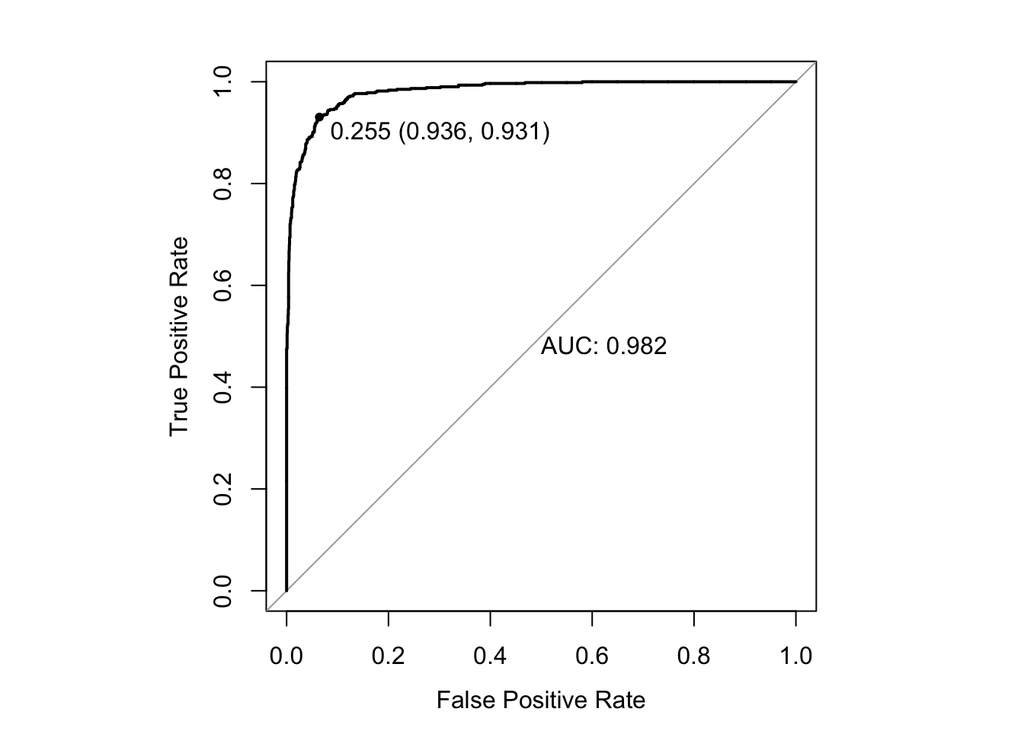

```
##
## Call:
## roc.default(response = hotpot$销量水平, predictor = fit$fitted.values,     plot = TRUE, legacy.axes = TRUE, xlab = "False Positive Rate",     ylab = "True Positive Rate", print.thres = TRUE, print.auc = TRUE)
##
## Data: fit$fitted.values in 2083 controls (hotpot$销量水平 低) < 605 cases (hotpot$销量水平 高).
## Area under the curve: 0.9816
```

```r
library(pROC)
par(pty = "s")
roc(hotpot$销量水平, fit$fitted.values, plot=TRUE, legacy.axes = TRUE,
    xlab = "False Positive Rate", ylab = "True Positive Rate" ,print.thres=TRUE, print.auc=TRUE)
```